# Simple Linear Regression

Edneide Ramalho

28 Setembro, 2021

# 1 Imports

```r
library(fst) # to read fst format
library(tidyverse)

# Data
taiwan_real_estate <-  read_fst(
  "taiwan_real_estate.fst",
  columns = NULL,
  from = 1,
  to = NULL,
  as.data.table = FALSE,
  old_format = FALSE
)

glimpse(taiwan_real_estate)
```

```
## Rows: 414
## Columns: 4
## $ dist_to_mrt_m   <dbl> 84.87882, 306.59470, 561.98450, 561.98450, 390.56840, …
## $ n_convenience   <dbl> 10, 9, 5, 5, 5, 3, 7, 6, 1, 3, 1, 9, 5, 4, 4, 2, 6, 1,…
## $ house_age_years <ord> 30 to 45, 15 to 30, 0 to 15, 0 to 15, 0 to 15, 0 to 15…
## $ price_twd_msq   <dbl> 11.467474, 12.768533, 14.311649, 16.580938, 13.040847,…
```

# 2 Categorical explanatory variables

- Syntax:

`lm(formula = mass_g ~ species, data = fish)`

## 2.1 Visualizing numeric vs. categorical

If the explanatory variable is categorical, the scatter plot that you used before to visualize the data doesn’t make sense. Instead, a good option is to draw a histogram for each category.

The Taiwan real estate dataset has a categorical variable in the form of the age of each house. The ages have been split into 3 groups: 0 to 15 years, 15 to 30 years, and 30 to 45 years.

Using `taiwan_real_estate`, plot a histogram of `price_twd_msq` with 10 bins. Facet the plot by `house_age_years` to give 3 panels.

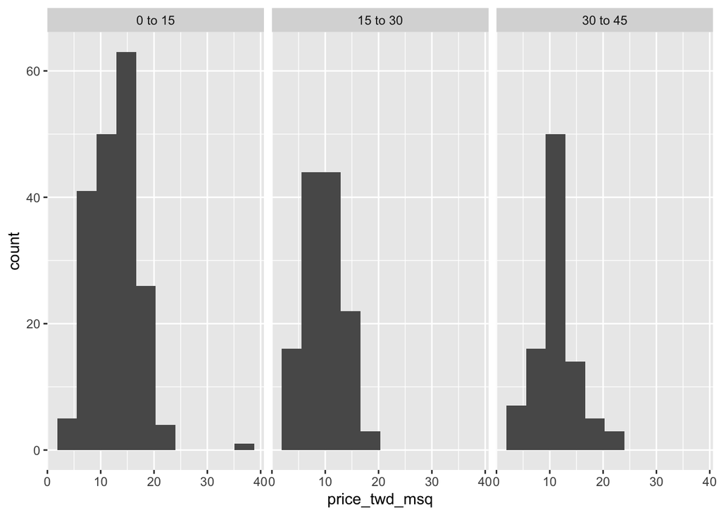

```r
# Using taiwan_real_estate, plot price_twd_msq
ggplot(taiwan_real_estate, aes(price_twd_msq)) +
  # Make it a histogram with 10 bins
  geom_histogram(bins = 10) +
  # Facet the plot so each house age group gets its own panel
  facet_wrap(vars(house_age_years))
```

## 2.2 Calculating means by category

A good way to explore categorical variables is to calculate summary statistics such as the mean for each category. Here, you’ll look at grouped means for the house prices in the Taiwan real estate dataset.

- Group `taiwan_real_estate` by `house_age_years`.
- Summarize to calculate the mean `price_twd_msq` for each group, naming the column `mean_by_group`.
- Assign the result to `summary_stats` and look at the numbers.

```r
summary_stats <- taiwan_real_estate %>%
  # Group by house age
  group_by(house_age_years) %>%
  # Summarize to calculate the mean house price/area
  summarize(mean_by_group = mean(price_twd_msq))

# See the result
summary_stats
```

```
## # A tibble: 3 x 2
##   house_age_years mean_by_group
##   <ord>                   <dbl>
## 1 0 to 15                 12.6
## 2 15 to 30                 9.88
## 3 30 to 45                11.4
```

## 2.3 lm() with a categorical explanatory variable

Linear regressions also work with categorical explanatory variables. In this case, the code to run the model is the same, but the coefficients returned by the model are different. Here you’ll run a linear regression on the Taiwan real estate dataset.

- Run a linear regression with `price_twd_msq` as the response variable, `house_age_years` as the explanatory variable, and `taiwan_real_estate` as the dataset. Assign to `mdl_price_vs_age`.

```r
# Run a linear regression of price_twd_msq vs. house_age_years
mdl_price_vs_age <- lm(price_twd_msq ~ house_age_years, data = taiwan_real_estate)

# See the result
mdl_price_vs_age
```

```
##
## Call:
## lm(formula = price_twd_msq ~ house_age_years, data = taiwan_real_estate)
##
## Coefficients:
##       (Intercept)  house_age_years.L  house_age_years.Q
##           11.3025            -0.8798             1.7462
```

- Update the model formula so that no intercept is included in the model. Assign to `mdl_price_vs_age_no_intercept`.

```r
# Update the model formula to remove the intercept
mdl_price_vs_age_no_intercept <- lm(
  price_twd_msq ~ house_age_years + 0,
  data = taiwan_real_estate
)

# See the result
mdl_price_vs_age_no_intercept
```

```
##
## Call:
## lm(formula = price_twd_msq ~ house_age_years + 0, data = taiwan_real_estate)
##
## Coefficients:
##  house_age_years0 to 15  house_age_years15 to 30  house_age_years30 to 45
##                  12.637                    9.877                   11.393
```